# Estudios de Informática, Multimedia y Telecomunicaciones

Vamos a analizar el riesgo según el número de créditos que tiene un cliente:

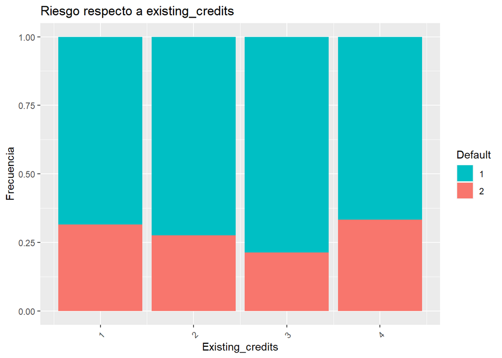

```r
# Gráfico
ggplot(data = df_copy, aes(x=existing_credits,fill=as.factor(default))) + geom_bar(position = "fill") +
  xlab("Existing_credits") +
  ylab("Frecuencia") +
  scale_fill_manual(name = "Default", values=c("#00bfc4","#f8766d")) +
  ggtitle("Riesgo respecto a existing_credits") +
  theme(axis.text.x = element_text(angle = 45, vjust = 0.6))
```

```r
# Tabla de contingencias
tabla_frec_abs <- table(df_copy$existing_credits, df_copy$default)
colnames(tabla_frec_abs) = c("No riesgo", "Sí riesgo")
tabla_frec_abs
```

```
##
##     No riesgo Sí riesgo
##   1       433       200
##   2       241        92
##   3        22         6
##   4         4         2
```

```r
prop.table(tabla_frec_abs, margin = 1)
```

```
##
##     No riesgo Sí riesgo
##   1 0.6840442 0.3159558
##   2 0.7237237 0.2762763
##   3 0.7857143 0.2142857
##   4 0.6666667 0.3333333
```

Vemos que no influye mucho el número de créditos respecto al riesgo de que no te concedan un préstamos, de hecho los riesgos son relativamente bajos, ya que solamente cuando tenemos 4 créditos nuestro riesgo es de un 33%, siendo éste el más alto.

Analizamos si el ser extranjero influye en la concesión de un préstamo:

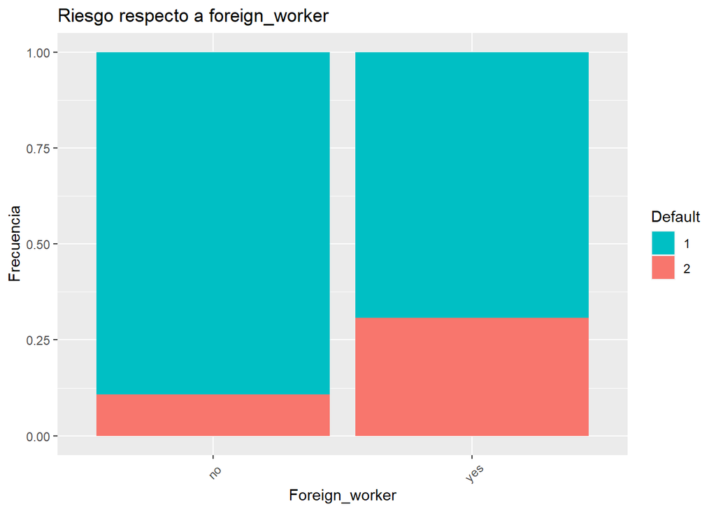

```r
# Gráfico
ggplot(data = df_copy, aes(x=foreign_worker,fill=as.factor(default))) + geom_bar(position = "fill") +
  xlab("Foreign_worker") +
  ylab("Frecuencia") +
  scale_fill_manual(name = "Default", values=c("#00bfc4","#f8766d")) +
  ggtitle("Riesgo respecto a foreign_worker") +
  theme(axis.text.x = element_text(angle = 45, vjust = 0.6))
```

```r
# Tabla de contingencias
tabla_frec_abs <- table(df_copy$foreign_worker, df_copy$default)
colnames(tabla_frec_abs) = c("No riesgo", "Sí riesgo")
tabla_frec_abs
```

```
##
##       No riesgo Sí riesgo
##   no         33         4
##   yes       667       296
```

```r
prop.table(tabla_frec_abs, margin = 1)
```

```
##
##       No riesgo Sí riesgo
##   no  0.8918919 0.1081081
##   yes 0.6926272 0.3073728
```

Vemos que es verdad que si eres extranjero tienes mayor riesgo de que no te concedan el préstamos, pero esto es relativo, ya que hay muy pocos registros de clientes que no sean extranjeros, para ser más exactos solo 37 registros de 1000 se corresponden con registros de clientes no extranjeros.

Finalmente, analizamos si el trabajo influye o no:

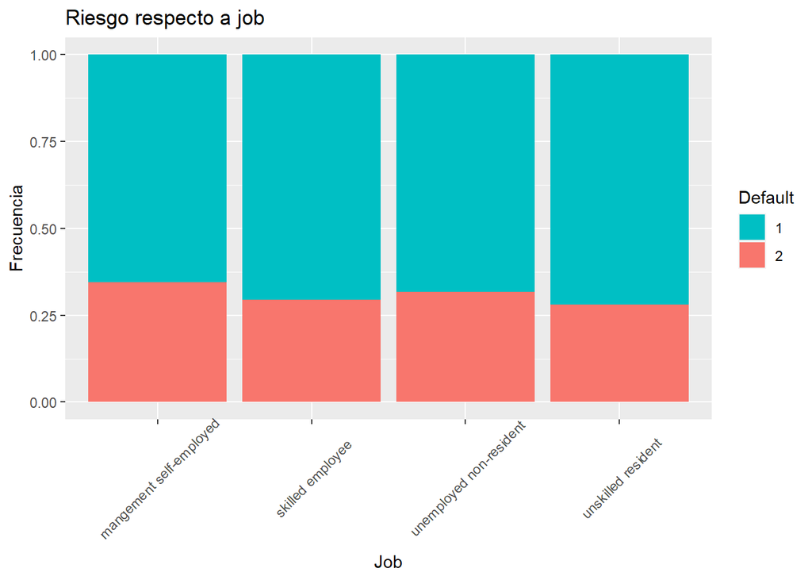

```r
# Gráfico
ggplot(data = df_copy, aes(x=job,fill=as.factor(default))) + geom_bar(position = "fill") +
  xlab("Job") +
  ylab("Frecuencia") +
  scale_fill_manual(name = "Default", values=c("#00bfc4","#f8766d")) +
  ggtitle("Riesgo respecto a job") +
  theme(axis.text.x = element_text(angle = 45, vjust = 0.6))
```

```r
# Tabla de contingencias
tabla_frec_abs <- table(df_copy$job, df_copy$default)
colnames(tabla_frec_abs) = c("No riesgo", "Sí riesgo")
tabla_frec_abs
```

```
##
##                           No riesgo Sí riesgo
##   mangement self-employed        97        51
##   skilled employee              444       186
##   unemployed non-resident        15         7
##   unskilled resident            144        56
```

```r
prop.table(tabla_frec_abs, margin = 1)
```

```
##
##                           No riesgo Sí riesgo
##   mangement self-employed 0.6554054 0.3445946
##   skilled employee        0.7047619 0.2952381
##   unemployed non-resident 0.6818182 0.3181818
##   unskilled resident      0.7200000 0.2800000
```

Vemos que la especialización del trabajo no influye a si se concede un préstamo o no, ya que todos los niveles presentan un riesgo relativamente bajo, siendo el más alto el de mangement self-employed con un 34%.

### 3.2.3 Correlaciones

Para terminar con el apartado del análisis y así poder realizar el modelo, vamos a ver cómo de correlacionadas están las variables numéricas de nuestro dataset, esto nos va a permitir hacenos una idea de si las variables independientes de nuestro modelo van a afectar a la variable objetivo, que en nuestro caso es predecir si dados unos datos el cliente supone un riesgo o no concederle el préstamos.

Para ello lo primero que debemos de hacer es quedarnos con las variables numéricas:

```r
df_copy_numeric = df_copy[, unlist(lapply(df_copy, is.numeric))]

head(df_copy_numeric)
```

```
##   months_loan_duration amount age existing_credits default
## 1                    6   1169  67                2       1
## 2                   48   5951  22                1       2
## 3                   12   2096  49                1       1
## 4                   42   7882  45                1       1
## 5                   24   4870  53                2       2
## 6                   36   9055  35                1       1
```

Vemos que salvando la variable objetivo que es default, solo tenemos cuatro variable numéricas según el proyecto que estamos realizando, por lo que vamos a ver cómo de correlacionadas están:

```r
cor(df_copy_numeric)
```

```
##                      months_loan_duration     amount         age
## months_loan_duration           1.00000000 0.62498420 -0.03613637
## amount                         0.62498420 1.00000000  0.03271642
## age                           -0.03613637 0.03271642  1.00000000
## existing_credits              -0.01128360 0.02079455  0.14925358
## default                        0.21492667 0.15473864 -0.09112741
##                      existing_credits     default
## months_loan_duration      -0.01128360  0.21492667
## amount                     0.02079455  0.15473864
## age                        0.14925358 -0.09112741
## existing_credits           1.00000000 -0.04573249
## default                   -0.04573249  1.00000000
```

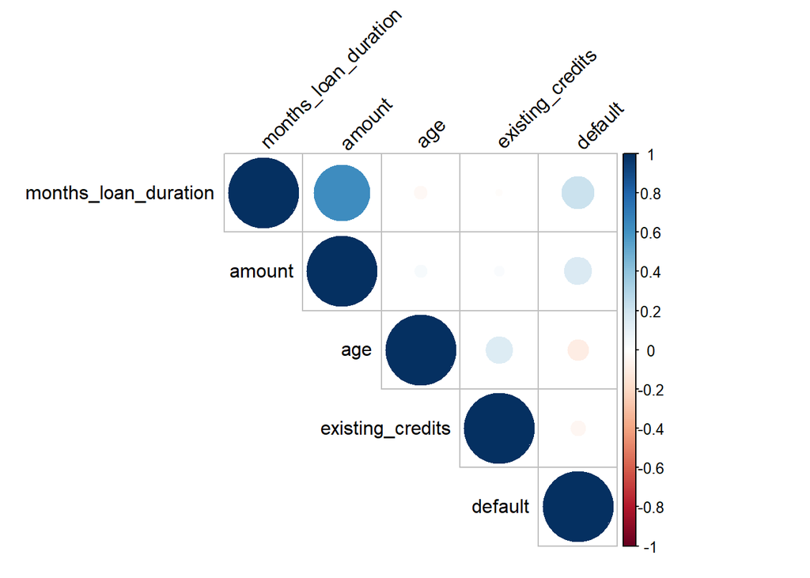

```r
corrplot(cor(df_copy_numeric), type = "upper",
         order = "original",
         tl.col = "black",
         tl.srt = 45)
```

De la anterior ejecución podemos observar que amount y months_loan_duration están altamente correlacionadas positivamente, es decir, cuando aumenta una variable la otra aumenta. Y respecto al análisis de default vemos que months_loan_duration y amount están un poco correlacionadas positivamente con default, y la edad respecto a default está muy poco correlacioanda negativamente con default.

Todas estas correlaciones no son del todo significativas, ya que solo podemos considerarlas como tal si la correlación en valor absoluto es superior a 0.7, pero tal y como podemos observar no es así, por lo que es interesante saber que estas variables están un poco correlacionadas pero no del todo (no sabemos cómo va a afectar a nuestro modelo si incluimos dichas variables o no).

## 3.3 Primer árbol de decisión

Una vez que ya hemos realizado todo el análisis del conjunto de datos, vamos a modelar el problema a partir de un árbol de decisión.

Por lo tanto, lo primero de todo es dividir el conjunto de datos inicial, en dos conjuntos: uno para entrenar el modelo y otro para realizar predicciones, pero antes debemos dividir los datos según la variable dependiente (default) y el resto de variables independientes:

```r
set.seed(0)

df_vObjetivo = df_copy$default
df_vIndependientes = df_copy[, -c(14)]
```

Ahora sí, creamos el conjunto de train y el de test, para el de train se usa 2/3 de los datos y para el de test 1/3:

```r
separacion = 3

indexes = sample(1:nrow(df_copy), size=floor(((separacion-1)/separacion)*nrow(df_copy)))
trainX = df_vIndependientes[indexes,]
trainy = df_vObjetivo[indexes]
testX = df_vIndependientes[-indexes,]
testy = df_vObjetivo[-indexes]
```

Comprobamos que no vamos a tener datos sesgados:

```r
summary(trainX)
```

```
##    checking_balance months_loan_duration                credit_history
##  < 0 DM    :183     Min.   : 4.00        critical              :191
##  > 200 DM  : 46     1st Qu.:12.00        delayed               : 63
##  1 - 200 DM:168     Median :18.00        fully repaid          : 26
##  unknown   :269     Mean   :20.39        fully repaid this bank: 34
##                     3rd Qu.:24.00        repaid                :352
##                     Max.   :60.00
##
##        purpose        amount           savings_balance  employment_length
##  radio/tv  :198   Min.   :  250   < 100 DM     :399    > 7 yrs   :169
##  car (new) :151   1st Qu.: 1364   > 1000 DM    : 28    0 - 1 yrs :113
##  furniture :121   Median : 2309   101 - 500 DM : 71    1 - 4 yrs :233
##  car (used): 70   Mean   : 3192   501 - 1000 DM: 47    4 - 7 yrs :109
##  business  : 57   3rd Qu.: 3914   unknown      :121    unemployed: 42
##  education : 34   Max.   :15857
##  (Other)   : 35
##       personal_status      age            housing    existing_credits
##  divorced male: 28    Min.   :19.00   for free: 77   Min.   :1.000
##  female       :209    1st Qu.:27.00   own     :466   1st Qu.:1.000
##  married male : 64    Median :33.00   rent    :123   Median :1.000
##  single male  :365    Mean   :35.69                  Mean   :1.402
##                       3rd Qu.:42.00                  3rd Qu.:2.000
##                       Max.   :75.00                  Max.   :4.000
##
##  foreign_worker                      job      d-months_loan_duration
##  no : 21        mangement self-employed: 90   Corto:247
##  yes:645        skilled employee       :421   Medio:366
##                 unemployed non-resident: 14   Largo: 53
##                 unskilled resident     :141
##
##
##
##     d-amount            d-age
##  Pequeña:292   Joven       :118
##  Mediana:277   Mediana-edad:421
##  Grande : 97   Mayor       :116
##                Viejo       : 11
##
##
##
```

```r
summary(trainy)
```

```
##    Min. 1st Qu.  Median    Mean 3rd Qu.    Max.
##   1.000   1.000   1.000   1.275   2.000   2.000
```

```r
summary(testX)
```

```
##    checking_balance months_loan_duration                credit_history
##  < 0 DM    : 91     Min.   : 4.00        critical              :102
##  > 200 DM  : 17     1st Qu.:12.00        delayed               : 25
##  1 - 200 DM:101     Median :18.00        fully repaid          : 14
##  unknown   :125     Mean   :21.92        fully repaid this bank: 15
##                     3rd Qu.:24.00        repaid                :178
##                     Max.   :72.00
##
##        purpose       amount           savings_balance  employment_length
##  car (new) :83   Min.   :  338   < 100 DM     :204    > 7 yrs   : 84
##  radio/tv  :82   1st Qu.: 1372   > 1000 DM    : 20    0 - 1 yrs : 59
##  furniture :60   Median : 2326   101 - 500 DM : 32    1 - 4 yrs :106
##  business  :40   Mean   : 3429   501 - 1000 DM: 16    4 - 7 yrs : 65
##  car (used):33   3rd Qu.: 4148   unknown      : 62    unemployed: 20
##  education :16   Max.   :18424
##  (Other)   :20
##       personal_status      age            housing    existing_credits
##  divorced male: 22    Min.   :20.00   for free: 31   Min.   :1.000
##  female       :101    1st Qu.:26.25   own     :247   1st Qu.:1.000
##  married male : 28    Median :33.00   rent    : 56   Median :1.000
##  single male  :183    Mean   :35.27                  Mean   :1.416
##                       3rd Qu.:41.00                  3rd Qu.:2.000
##                       Max.   :75.00                  Max.   :4.000
##
##  foreign_worker                      job      d-months_loan_duration
##  no : 16        mangement self-employed: 58   Corto:112
##  yes:318        skilled employee       :209   Medio:188
##                 unemployed non-resident:  8   Largo: 34
##                 unskilled resident     : 59
##
##
##
##     d-amount            d-age
##  Pequeña:140   Joven       : 72
##  Mediana:142   Mediana-edad:203
##  Grande : 52   Mayor       : 52
##                Viejo       :  7
##
##
##
```

```r
summary(testy)
```

```
##    Min. 1st Qu.  Median    Mean 3rd Qu.    Max.
##    1.00    1.00    1.00    1.35    2.00    2.00
```

De la ejecución anterior vemos que tanto el conjunto de entrenamiento como el conjunto de test no presentan una gran diferencia entre sus valores, por lo que la informacón no nos va a quedar sesgada.

Una vez que ya tenemos los conjuntos de dastos podemos crear y entrenar el modelo. Aunque el conjunto de datos de las variables independientes tienen 16 atributos, si introducimos todos ellos al modelo no nos va a proporcionar un árbol visualmente legible, es por ello que hemos decidido seleccionar tres variables.

Las tres variables seleccionadas son: savings_balance, checking_balance y months_loan_duration. Se han elegido estas variables y no otras por el análisis que hemos hecho de los datos anteriormente. Además, a modo de prueba se creó un modelo con todas las variables y vimos que las que mejor discriminaban los datos eran estas.

Una vez seleccionadas las variables creamos el modelo, el cual nos va a dar un punto de salida:

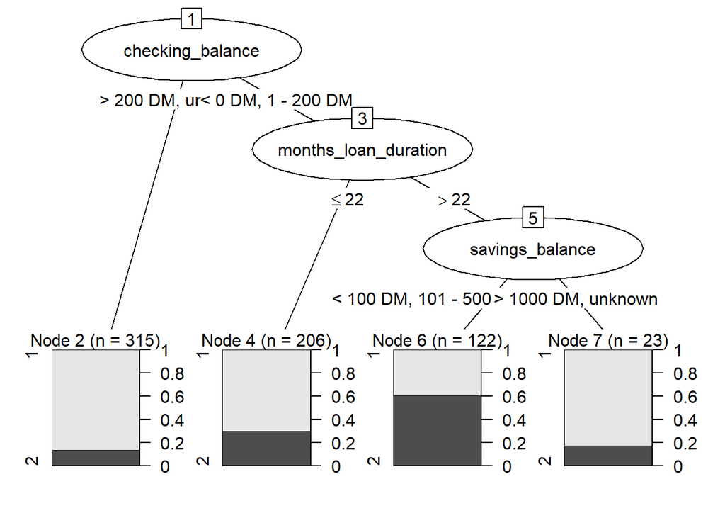

```r
#c("months_loan_duration", "employment_length", "checking_balance", "credit_history")
#c("months_loan_duration", "purpose", "savings_balance", "checking_balance", "credit_history")
#c("savings_balance", "checking_balance", "credit_history")

# modelo_c50_basico <- C50::C5.0(x = trainX[, c("savings_balance", "checking_balance", "months_loan_duration")], y = as.factor(trainy), rules = TRUE)
#
# summary(modelo_c50_basico)

modelo_c50_basico <- C50::C5.0(x = trainX[, c("savings_balance", "checking_balance", "months_loan_duration")], y = as.factor(trainy))

plot(modelo_c50_basico)
```

# 4 Rúbrica

- (Obligatorio) Se debe realizar un breve informe (PDF, Html…. ) donde se respondan a las preguntas concretas, mostrando en primer lugar el código utilizado, luego los resultados y posteriormente los comentarios que se consideren pertinentes para cada apartado.
- 10% Hay un estudio sobre los datos de los que se parte, las variables que componen los datos. Los datos son preparados correctamente.
- 10% Se realiza un análisis descriptivo univariante (o análisis de relevancia) de algunas variables una vez se han tratado vs el target a nivel gráfico, comentando las que aparentemente son más interesantes. Análogamente se realiza un análisis de correlaciones.
- 20% Se aplica un árbol de decisión de forma correcta y se obtiene una estimación del error, mostrando gráficamente el árbol obtenido. La visualización debe ser comprensible y adecuada al problema a resolver.
- 15% Se explican las reglas que se obtienen en términos concretos del problema a resolver.
- 15% Se usa el modelo para predecir con muestras no usadas en el entrenamiento (holdout) y se obtiene una estimación del error. En base a la matriz de confusión, se comentan los tipos de errores y se valora de forma adecuada la capacidad predictiva del algoritmo.
- 15% Se prueba otro modelo de árbol o variantes diferentes del C50 y se comparan los resultados obtenidos, valorando si son mejores.
- 10% Se presenta unas conclusiones donde se expone un resumen de los diferentes modelos utilizados (al menos 3) así como el conocimiento adquirido tras el trabajo realizado y los descubrimientos más importantes realizados en el conjunto de datos.
- 5% Se presenta el código y es fácilmente reproducible.